# Generalised Linear Models

Matthew Talluto

23.02.2022

# Another thought experiment

Birds of prey often pass by high-altitude areas in relatively large numbers during the fall migration season. You and 50 friends go to 50 different mountaintops in the alps and count passing raptors for one hour.

Assuming an average rate of 2 raptors passing per hour, how many birds does each friend see? What distribution describes this?

# Another thought experiment

Birds of prey often pass by high-altitude areas in relatively large numbers during the fall migration season. You and 50 friends go to 50 different mountaintops in the alps and count passing raptors for one hour.

Assuming an average rate of 2 raptors passing per hour, how many birds does each friend see? What distribution describes this?

**Intuition**: there will be variability, some will see 0, most will see 2. Five is possible, ten is unlikely.

# Another thought experiment

Birds of prey often pass by high-altitude areas in relatively large numbers during the fall migration season. You and 50 friends go to 50 different mountaintops in the alps and count passing raptors for one hour.

Assuming an average rate of 2 raptors passing per hour, how many birds does each friend see? What distribution describes this?

**Intuition**: there will be variability, some will see 0, most will see 2. Five is possible, ten is unlikely.

The probability $p_k$ of observing $k$ events with a constant rate *is given by a simple equation:

$$p_k = \frac{\lambda^k e^{-\lambda}}{k!}$$

```r
lambda = 2 # two raptors per hour, observed for one hour
k = 0
(lambda^k * exp(-lambda)/factorial(k))
```

```
## [1] 0.1353353
```

```r
k = 1
(lambda^k * exp(-lambda)/factorial(k))
```

```
## [1] 0.2706706
```

```r
k = 0:10
probs = (lambda^k * exp(-lambda)/factorial(k))
ggplot(data.frame(k = factor(k), prob = probs), aes(x = k, y = probs)) + geom_col() + ylab("Probability")
```

[output not shown]

# Poisson distributions

A random process whereby uncommon (n < 20) events occur with a fixed probability is a Poisson process, and our observations or raptors will follow a Poisson distribution.

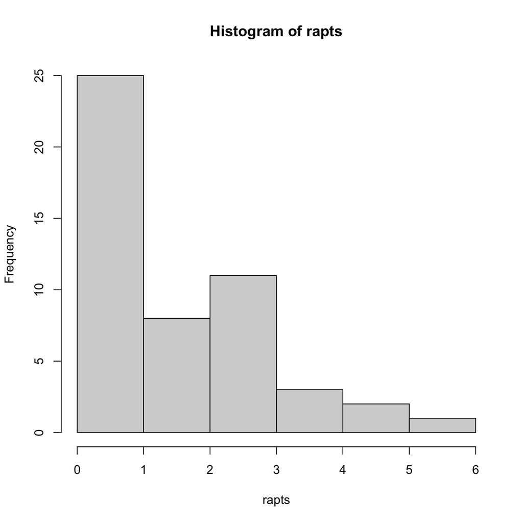

```r
# simulate the experiment
rapts = rpois(50, 2)
hist(rapts)
```

## General linear models

> Matt, add that Epsilon is Y_hat? But I see that Y_hat may be a bit disturbing in the definition of theta later on. I was a bit notation-confused but also I haven´t actually listened to your LR-talk, where you also used epsilon alreaady…

$$\mathbb{E}(y) = \mathbf{B}\mathbf{X}$$

$n$ observations of $y$, $n$ observations of $k$ $x$-variables, $k$-length coefficient vector.

$$\begin{bmatrix}
\mathbb{E}(y_1) \\ \mathbb{E}(y_2) \\ \vdots \\ \mathbb{E}(y_n)
\end{bmatrix}
=
\begin{bmatrix}
b_0 & b_1 & ~b_2 & \dots & b_k
\end{bmatrix}
\times
\begin{bmatrix}
1 & x_{1,1} & x_{2,1} & \dots & x_{k,1} \\
1 & x_{1,2} & x_{2,2} & \dots & x_{k,2} \\
\vdots & \vdots & \vdots & \dots & \vdots \\
1 & x_{1,n} & x_{2,n} & \dots & x_{k,n} \\
\end{bmatrix}$$

# General linear models

$$\mathbb{E}(\mathbf{Y}) = \mathbf{B}\mathbf{X}$$

$n$ observations of $j$ $y-$variables, $n$ observations of $k$ $x$-variables, $k \times j$-length coefficient matrix.

$$\begin{bmatrix}
\mathbb{E}(y_{1,1}) & \mathbb{E}(y_{2,1}) & \dots & \mathbb{E}(y_{j,1}) \\
\mathbb{E}(y_{1,2}) & \mathbb{E}(y_{2,2}) & \dots & \mathbb{E}(y_{j,2}) \\
\vdots & \vdots & \vdots & \dots & \vdots \\
\mathbb{E}(y_{1,n}) & \mathbb{E}(y_{2,n}) & \dots & \mathbb{E}(y_{j,n}) \\
\end{bmatrix}
=
\begin{bmatrix}
b_{1,1} & b_{2,1} & \dots & b_{k,1} \\
b_{1,2} & b_{2,2} & \dots & b_{k,2} \\
\vdots & \vdots & \vdots & \dots & \vdots \\
b_{1,j} & b_{2,j} & \dots & b_{k,j} \\
\end{bmatrix}
\times
\begin{bmatrix}
1 & x_{1,1} & x_{2,1} & \dots & x_{k,1} \\
1 & x_{1,2} & x_{2,2} & \dots & x_{k,2} \\
\vdots & \vdots & \vdots & \dots & \vdots \\
1 & x_{1,n} & x_{2,n} & \dots & x_{k,n} \\
\end{bmatrix}$$

# Changing the conditional distribution of y

- What if $y$ doesn’t come from a normal distribution?
- We can easily relax this assumption!

$$\begin{aligned}
\mathbb{E}(y) & = \mathbf{B}\mathbf{X} \\
\theta & = \mathcal{f}\left [\mathbb{E}\left (y \right), \phi \right ] \\
y & \sim \mathcal{D}(\theta)
\end{aligned}$$

- $\theta$ is a vector of **distribution parameters**, used to parameterize a generic distribution $\mathcal{D}$.
- $\phi$ is a **dispersion** or **precision** parameter
  - e.g., if $\mathcal{D}$ is a normal distribution, $\phi = s_\epsilon$

# Link functions

- This model assumes a linear relationship between $\mathbb{E}(y)$ and $\mathbf{B}\mathbf{X}$.
  $$\begin{aligned}
  \mathbb{E}(y) & = \mathbf{B}\mathbf{X} \\
  \theta & = \mathcal{f}\left [\mathbb{E}\left (y \right), \phi \right ] \\
  y & \sim \mathcal{D}(\theta)
  \end{aligned}$$
- This can be a problem for some distributions
- A straight line can predict impossible values for $\mathbb{E}(y)$!

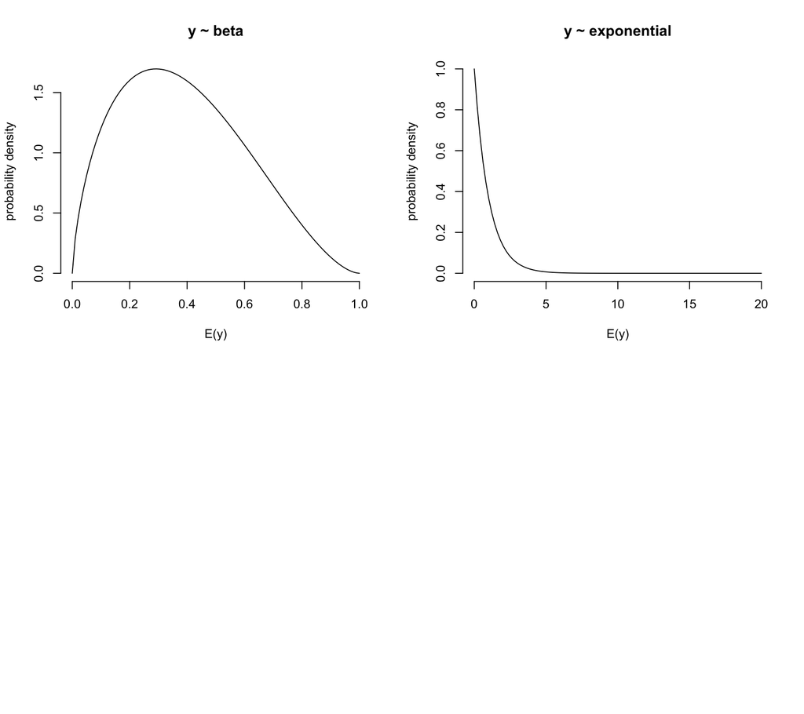

# Linearity assumption revisited

- This model assumes a linear relationship between $\mathbb{E}(y)$ and $\mathbf{B}\mathbf{X}$.
- This can be a problem for some distributions
- A straight line can predict impossible values for $\mathbb{E}(y)$!

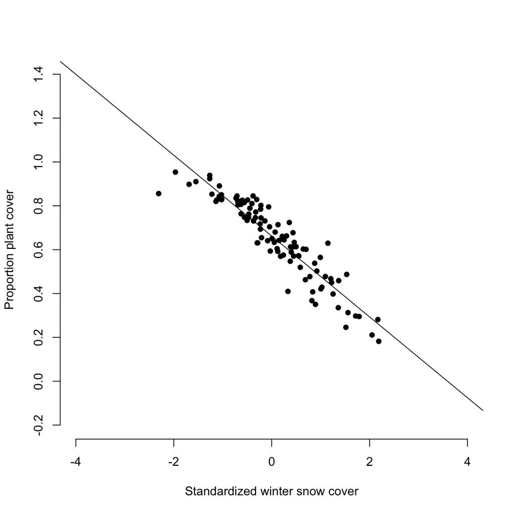

# Linearity assumption revisited

- This model assumes a linear relationship between $\mathbb{E}(y)$ and $\mathbf{B}\mathbf{X}$.
- This can be a problem for some distributions
- A straight line can predict impossible values for $\mathbb{E}(y)$!

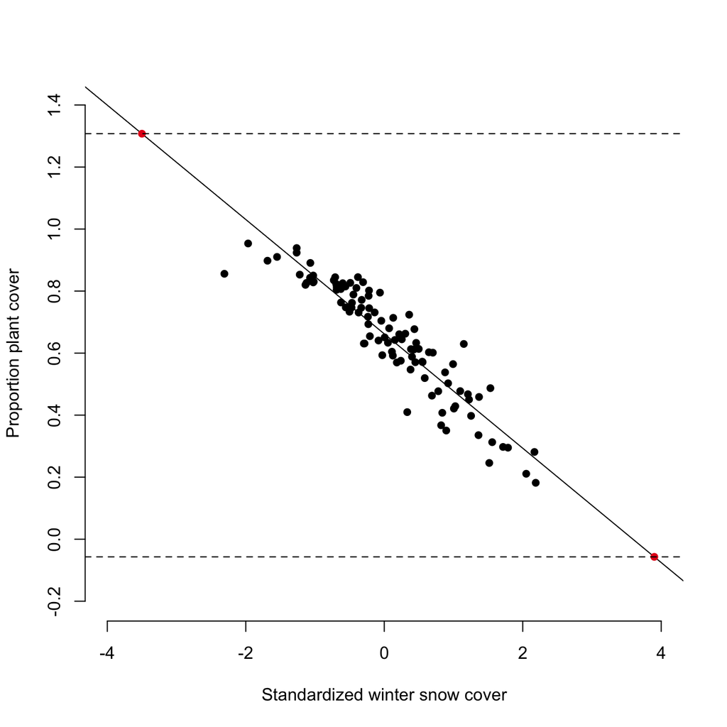

# Transforming the expectation

- This model assumes a linear relationship between $\mathbb{E}(y)$ and $\mathbf{B}\mathbf{X}$.
- This can be a problem for some distributions
- A straight line can predict impossible values for $\mathbb{E}(y)$!
- To transform $y$, we need a way to **link** sensible values for $\mathbb{E}(y)$ to the linear term $\mathbf{BX}$

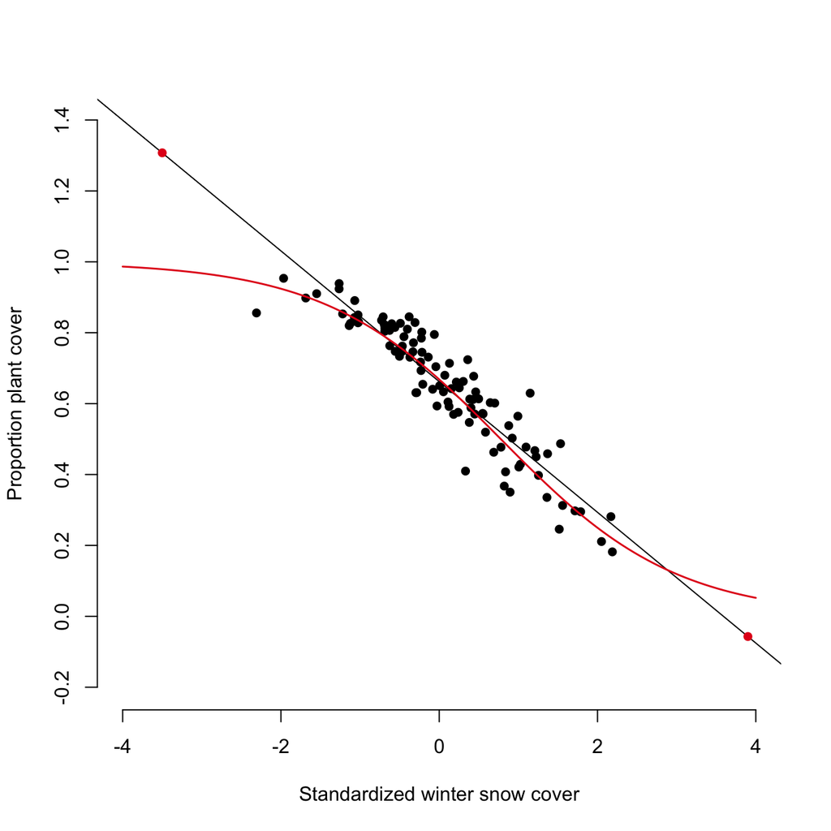

# Why not lm?

- This model assumes a linear relationship between $\mathbb{E}(y)$ and $\mathbf{B}\mathbf{X}$.
- This can be a problem for some distributions
- A straight line can predict impossible values for $\mathbb{E}(y)$!
- To transform $y$, we need a way to **link** sensible values for $\mathbb{E}(y)$ to a linear equation $a + \mathbf{BX}$
- `lm` with transformed y is biased!

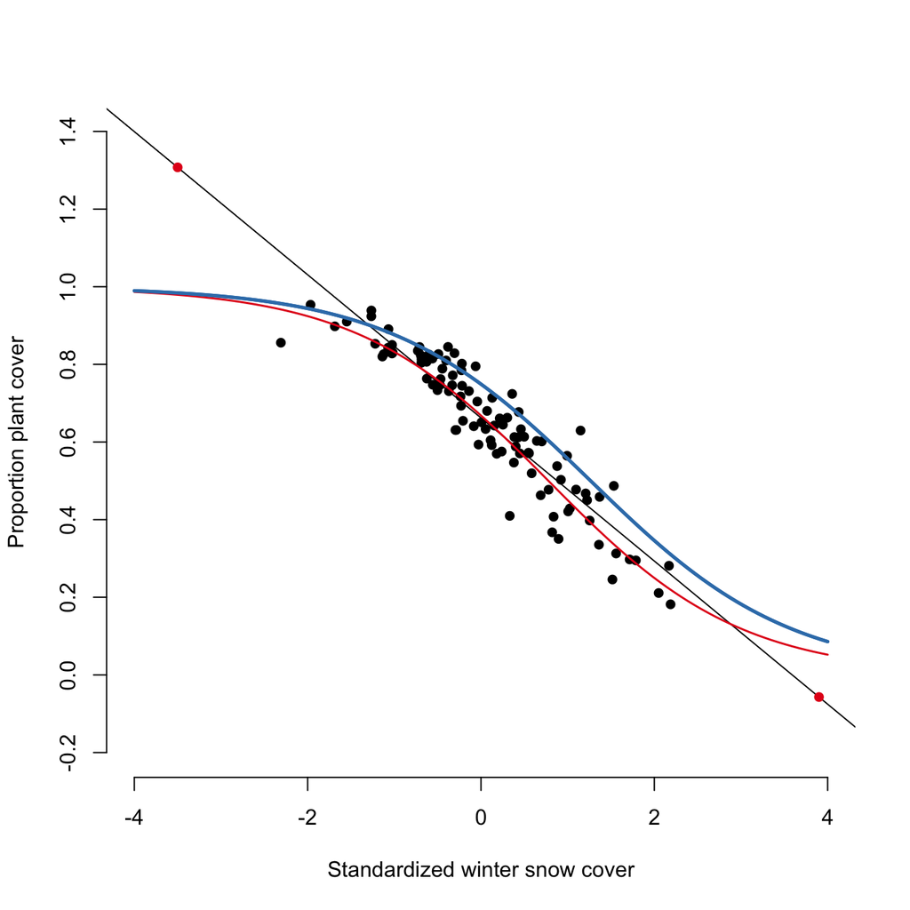

# Why not lm?

- Recall the problem for many non-linear transformations:

$$\mathcal{f} \left [\mathbb{E}\left (y \right ) \right] \ne \mathbb{E}\left (\mathcal{f} \left [y \right] \right )$$

> here we could link back to the Hydropsyche regression example if we do this one with lm() and nlm() and point out the differences there already. I think that´s equivalent to the problem of lm brought up here.

# Link functions

- To properly transform $y$, we need a way to **link** sensible values for $\mathbb{E}(y)$ to the linear term $\mathbf{BX}$
- The linear term is defined for all real numbers: $(-\infty, \infty)$, while $\mathbb{E}(y)$ is in $[0,1]$
- If $y$ is a proportion or probability, the **log-odds** (aka **logit**) function works well

$$\begin{aligned}
\log \frac{\mathbb{E}(y)}{1-\mathbb{E}(y)} & = \mathbf{BX} \\
\mathrm{logit} \left[ \mathbb{E}\left (y \right ) \right] & = \mathbf{BX} \\
\mathbb{E}(y) & = \mathrm{logit}^{-1} (\mathbf{BX}) \\
\mathbb{E}(y) & = \frac{\mathrm{e}^{\mathbf{BX}}}{1 + \mathrm{e}^{\mathbf{BX}}}
\end{aligned}$$
* In R, $\mathrm{logit}(y)$ is `qlogis(y)` and $\mathrm{logit}^{-1}(x)$ is `plogis(x)`

> understanding issue from Gabriel: We start here with f(y) which - just a few pages before - we argued not to do. Not sure if I get it.

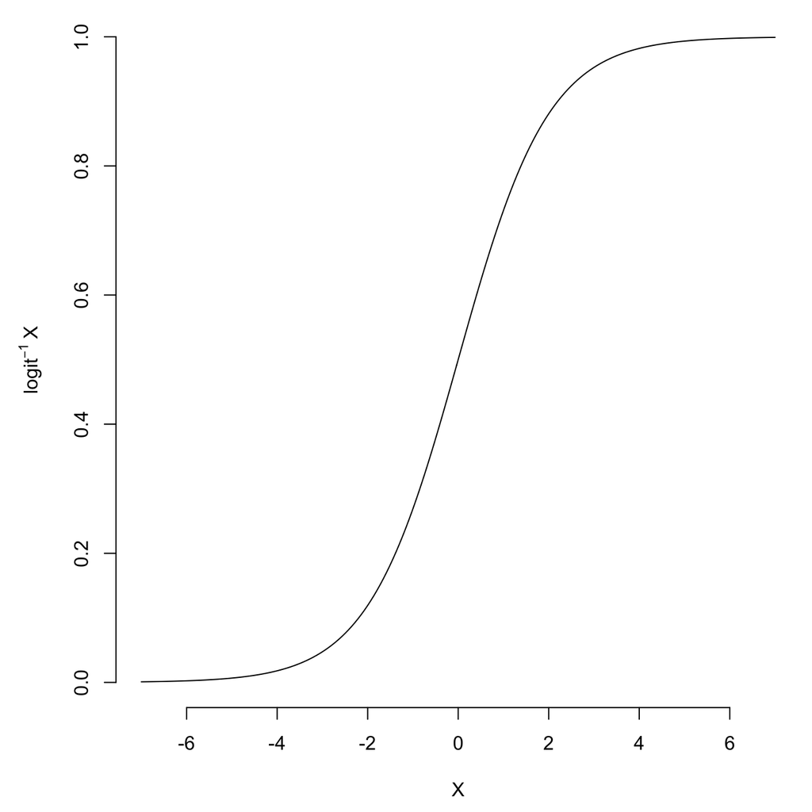

# The generalised linear model (glm)

$$\begin{aligned}
\mathrm{L} \left[ \mathbb{E}\left(y \right) \right] & = \mathbf{B}\mathbf{X} \\
\mathbb{E}(y) & = \mathrm{L}^{-1}(\mathbf{B}\mathbf{X}) \\
\theta & = \mathcal{f}\left [\mathbb{E}\left (y \right), \phi \right ] \\
y & \sim \mathcal{D}(\theta)
\end{aligned}$$

- $\mathrm{L}$ is the **link function**
- $\theta$ is a vector of **distribution parameters**, used to parameterize a generic distribution $\mathcal{D}$.
- $\phi$ is a **dispersion** or **precision** parameter
- Linear regression is a special case of the GLM, where
  - $\mathrm{L}$ is the **identity function**: $\mathrm{L}(x) = x$
  - $\mathcal{f}$ is also the **identity function**
  - $\mathcal{D}$ is a normal distribution with mean $\mathbb{E}(y)$ and constant variance $\sigma = \phi$

# Discrete events - Binomial models

- We observe an event happening $k$ times out of $n$ attempts/possibilities
  - $k_1$ of $n_1$ people in the vaccine group got COVID, compared to $k_c$ of $n_c$ in the control
  - we marked $n$ animals and recovered $k$ a week later
  - $k$ of $n$ trees in forest monitoring plots were alive when the plots were surveyed
- Also works for binary data (i.e., $n=1$)
  - A species is present or absent in experimental units (species distribution modelling)

We use a **binomial** distribution with a **logit** or **probit link**

The expectation of y is the probability that an event occurs

$$\begin{aligned}
p & = \mathrm{logit}^{-1}(\mathbf{BX}) \\
y & \sim \mathrm{Binomial}(p)
\end{aligned}$$

**Constraint:** $\sigma^2_{y|\mathbf{X},n} = np(1-p)$

Binomial models are fairly robust to this assumption

# True counts - Poisson models

- Often, we have so-called true counts (trials/$n$ are unknown, infinite, nonsensical)
- Can also be expressed as a *rate*
  - number of species observed per unit area
  - number of fish crossing a fish ladder per hour
  - abundance per sampling effort

These data can be modelled with a **poisson** distribution, conventionally with a **log link**

The expectation of y is the rate at which the counts accumulate (in units of counts per sampling unit)

$$\begin{aligned}
\lambda & = \exp(\mathbf{BX}) \\
y & \sim \mathrm{Poisson}(\lambda)
\end{aligned}$$

**Constraint:** $\sigma^2_{y|\mathbf{X}} = \mathbb{E}(y|\mathbf{X}) = \lambda$

check this with the **dispersion** parameter in the GLM output

- Sometimes, *exposure* varies by observation.
  - Different size plots
  - Different observation times
  - We can add this to the model on the log scale using the `offset` parameter

# Poisson example: technology on islands

**Hypothesis**: The rate of technological development $\lambda_{\mathrm{tools}}$ among indigenous populations increases with log-population size.

> log-transform $x$ because at some point, the benefit of increasing population levels off

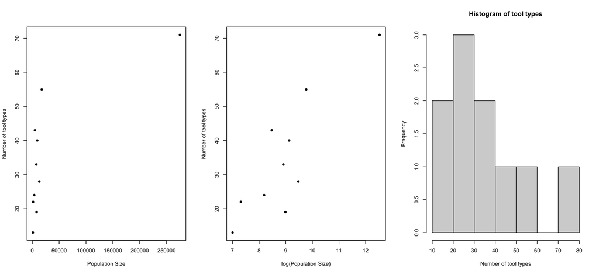

```r
tools = data.frame(
  culture = c("Malekula", "Tikopia", "Santa Cruz", "Yap", "Lau Fiji",
              'Trobriand', 'Chuuk', 'Manus', 'Tonga', 'Hawaii'),
  tool_types = c(13,22,24,43,33,19,40,28,55,71),
  population = c(1100, 1500, 3600, 4791, 7400, 8000, 9200, 13000, 17500, 275000),
  contact = factor(c("lo", "lo", "lo", "hi", "hi", "hi", "hi", "lo", "hi", "lo")),
  age_ky = c(0.5, 0.7, 3.3, 1, 3.5, 3.3, 2.2, 3, 2.9, 1.1)  ## wild guesses from instructor :-)
)
par(mfrow=c(1,3))
plot(tool_types ~ population, pch=16, data=tools, ylab="Number of tool types", xlab="Population Size")
plot(tool_types ~ log(population), pch=16, data=tools, ylab="Number of tool types", xlab="log(Population Size)")
hist(tools$tool_types, main="Histogram of tool types", xlab="Number of tool types")
```

(Kline Michelle A. and Boyd Robert 2010. Population size predicts technological complexity in Oceania. Proc. R. Soc. B.277: 2559–2564)

# Poisson example

```r
mod1 = glm(tool_types ~ log(population), data = tools, family = poisson)
mod2 = glm(tool_types ~ log(population)+contact, data = tools, family = poisson)
mod3 = glm(tool_types ~ log(population)+contact, data = tools, family = poisson, offset = log(age_ky))

summary(mod1)
```

```
##
## Call:
## glm(formula = tool_types ~ log(population), family = poisson,
##     data = tools)
##
## Deviance Residuals:
##     Min       1Q   Median       3Q      Max
## -2.5820  -1.2603  -0.2643   0.8369   2.4620
##
## Coefficients:
##                 Estimate Std. Error z value Pr(>|z|)
## (Intercept)      1.32852    0.30361   4.376 1.21e-05 ***
## log(population)  0.23980    0.03119   7.689 1.48e-14 ***
## ---
## Signif. codes:  0 '***' 0.001 '**' 0.01 '*' 0.05 '.' 0.1 ' ' 1
##
## (Dispersion parameter for poisson family taken to be 1)
##
##     Null deviance: 78.650  on 9  degrees of freedom
## Residual deviance: 25.292  on 8  degrees of freedom
## AIC: 82.058
##
## Number of Fisher Scoring iterations: 4
```

```r
summary(mod2)
```

```
##
## Call:
## glm(formula = tool_types ~ log(population) + contact, family = poisson,
##     data = tools)
##
## Deviance Residuals:
##     Min       1Q   Median       3Q      Max
## -3.2819  -0.5941   0.1464   0.8419   1.7783
##
## Coefficients:
##                 Estimate Std. Error z value Pr(>|z|)
## (Intercept)       1.2224     0.3231   3.783 0.000155 ***
## log(population)   0.2661     0.0346   7.691 1.46e-14 ***
## contactlo        -0.2984     0.1137  -2.624 0.008682 **
## ---
## Signif. codes:  0 '***' 0.001 '**' 0.01 '*' 0.05 '.' 0.1 ' ' 1
##
## (Dispersion parameter for poisson family taken to be 1)
##
##     Null deviance: 78.650  on 9  degrees of freedom
## Residual deviance: 18.283  on 7  degrees of freedom
## AIC: 77.049
##
## Number of Fisher Scoring iterations: 4
```

```r
summary(mod3)
```

```
##
## Call:
## glm(formula = tool_types ~ log(population) + contact, family = poisson,
##     data = tools, offset = log(age_ky))
##
## Deviance Residuals:
##     Min       1Q   Median       3Q      Max
## -4.5206  -2.4837   0.8384   3.2036   7.0014
##
## Coefficients:
##                 Estimate Std. Error z value Pr(>|z|)
## (Intercept)     -0.35669    0.38130  -0.935    0.350
## log(population)  0.33292    0.04080   8.161 3.33e-16 ***
## contactlo        0.09638    0.11368   0.848    0.397
## ---
## Signif. codes:  0 '***' 0.001 '**' 0.01 '*' 0.05 '.' 0.1 ' ' 1
##
## (Dispersion parameter for poisson family taken to be 1)
##
##     Null deviance: 204.52  on 9  degrees of freedom
## Residual deviance: 139.79  on 7  degrees of freedom
## AIC: 198.56
##
## Number of Fisher Scoring iterations: 5
```

```r
## Investigate for overdispersion
## empirical dispersion parameter... expect it to be equal to one!
mod1$deviance / mod1$df.residual
```

```
## [1] 3.161459
```

```r
mod2$deviance / mod2$df.residual
```

```
## [1] 2.611828
```

```r
mod3$deviance / mod3$df.residual
```

```
## [1] 19.97063
```

```r
## Look at AIC of the 3 models
## Minimum is "best" model
## Models < 2 delta are very similar to best
## Models 2-10 delta have some support, but inferior
## Models >10 have basically no support
aictab = data.frame(model = c("pop only", "pop+contact", "pop+contact+offset"),
          aic = c(AIC(mod1), AIC(mod2), AIC(mod3)))
aictab$delta = aictab$aic - min(aictab$aic)
aictab
```

```
##                model       aic      delta
## 1           pop only  82.05826   5.008875
## 2        pop+contact  77.04939   0.000000
## 3 pop+contact+offset 198.56103 121.511641
```

# Poisson example

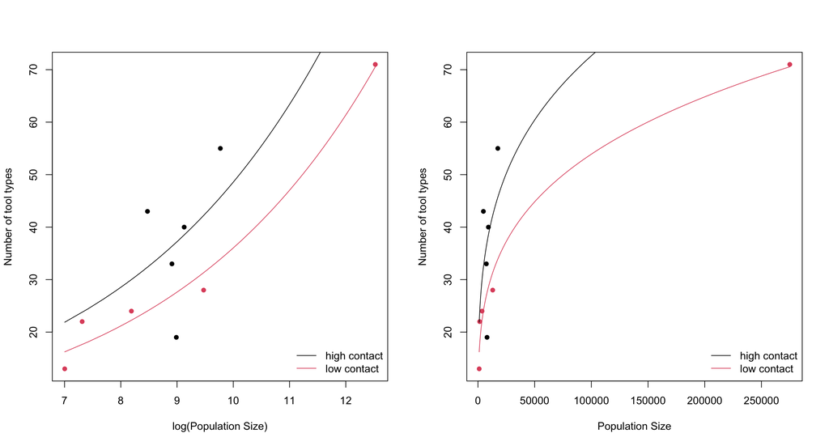

```r
par(mfrow=c(1,2))
plot(tool_types ~ log(population), pch=16, col = tools$contact,
     data=tools, ylab="Number of tool types", xlab="log(Population Size)")
new_hi = data.frame(population = seq(min(tools$population), max(tools$population), length.out = 500),
                    contact = "hi")
pr_hi = predict(mod2, type='response', newdata = new_hi)
new_lo = data.frame(population = seq(min(tools$population), max(tools$population), length.out = 500),
                    contact = "lo")
pr_lo = predict(mod2, type='response', newdata = new_lo)
lines(log(new_hi$population), pr_hi)
lines(log(new_lo$population), pr_lo, col=2)
legend("bottomright", legend=c("high contact", "low contact"), col=1:2, lwd=1, bty='n')

plot(tool_types ~ population, pch=16, col = tools$contact,
     data=tools, ylab="Number of tool types", xlab="Population Size")
lines(new_hi$population, pr_hi)
lines(new_lo$population, pr_lo, col=2)
legend("bottomright", legend=c("high contact", "low contact"), col=1:2, lwd=1, bty='n')
```

# What to do if overdispersed?

1. Consider adding predictors if possible (and x-transformations)
2. Consider if exposure is really constant (for Poisson)
3. Fit models with more flexible variance (e.g., negative binomial instead of Poisson)
4. Are there more zeros than expected? (finite mixture models)
5. Consult a statistician

# Continuous, strictly positive data

- Often used for costs, waiting times
  - ecosystem services modelling
  - animal movement
  - life expectancy
- Generally assume the coefficient of variation is constant
- Use a **gamma** likelihood and **inverse** or **log** link